# ITNPBD2 Representing and Manipulating Data

# A Consultancy Job for JC Penney

This notebook forms the assignment instructions and submission document of the assignment for ITNPBD2. Read the instructions carefully and enter code into the cells as indicated.

You will need these five files, which were in the Zip file you downloaded from the course webpage:

- jcpenney_reviewers.json
- jcpenney_products.json
- products.csv
- reviews.csv
- users.csv

The data in these files describes products that have been sold by the American retail giant, JC Penney, and reviews by customers who bought them. Note that the product data is real, but the customer data is synthetic.

Your job is to process the data, as requested in the instructions in the markdown cells in this notebook.

# Completing the Assignment

Rename this file to be xxxxxx_BD2 where xxxxxx is your student number, then type your code into the boxes provided. Each question is given in a markdown call, and there is an empty box beneath each one where you enter your answer. These boxes should contain 2 things:

- **The code that performs the required task**
- **Comments that explain your code**

# Marking Scheme

The assessment will be marked against the university Common Marking Scheme (CMS)

Here is a summary of what you need to achieve to gain a grade in the major grade bands:

| Grade | Requirement |
| --- | --- |
| Fail | Code does not run or does not achieve even the basics of the task, and you have not given any indications or explanations for choices of methods or intentions. |
| Pass | You must submit sufficient working code to show that you have mastered the basics of the task, even if not everything works completely. You include some justifications for choice of methods, but witho… |
| Merit | Your code is mostly correct, with only small problems or parts missing, and your comments are useful. Most choices for methods and structures are explained and alternatives are mentioned. |
| Distinction | Your code is working, correct, and well commented and shows an appreciation of style, efficiency and reliability. All choices for methods and structures are concisely justified and alternatives are gi… |

The full details of the CMS can be found here

https://www.stir.ac.uk/about/professional-services/student-academic-and-corporate-services/academic-registry/academic-policy-and-practice/quality-handbook/assessment-policy-and-procedure/appendix-2-postgraduate-common-marking-scheme/

Note that this means there are not certain numbers of marks allocated to each stage of the assignment. Your grade will reflect how well your solutions and comments demonstrate that you have achieved the learning outcomes of the task. The assessment is in two parts. Questions 1 to 17 require you to answer a specific question, but question 18 is broader and less prescriptive. Question 18 gives you the opportunity to show some creative thinking and analysis.

## Submission

When you are ready to submit, download your notebook as HTML by going to File->Download as->HTML in the menu. Make sure you have run all the cells and that their output is displayed. You can then submit the file on Canvas.

Late penalties will apply at a rate of three marks per day. Extensions will be considered under acceptable circumstances outside your control.

## Academic Integrity

This is an individual assignment, and so all submitted work must be fully your own work.

The University of Stirling is committed to protecting the quality and standards of its awards. Consequently, the University seeks to promote and nurture academic integrity, support staff academic integrity, and support students to understand and develop good academic skills that facilitate academic integrity.

In addition, the University deals decisively with all forms of Academic Misconduct.

Where a student does not act with academic integrity, their work or behaviour may demonstrate Poor Academic Practice or it may represent Academic Misconduct.

### Poor Academic Practice

Poor Academic Practice is defined as: "The submission of any type of assessment with a lack of referencing or inadequate referencing which does not effectively acknowledge the origin of words, ideas, images, tables, diagrams, maps, code, sound and any other sources used in the assessment."

### Academic Misconduct

Academic Misconduct is defined as: "any act or attempted act that does not demonstrate academic integrity and that may result in creating an unfair academic advantage for you or another person, or an academic disadvantage for any other member or member of the academic community."

Plagiarism is presenting somebody else’s work as your own. Plagiarism is a form of academic misconduct and is taken very seriously by the University. Students found to have plagiarised work can have marks deducted and, in serious cases, even be expelled from the University. Do not submit any work that is not entirely your own. Do not collaborate with or get help from anybody else with this assignment.

The University of Stirling's full policy on Academic Integrity can be found at:

https://www.stir.ac.uk/about/professional-services/student-academic-and-corporate-services/academic-registry/academic-policy-and-practice/quality-handbook/academic-integrity-policy-and-academic-misconduct-procedure/

# 1) Open both json files and read the contents of each into a string

We will start with the JSON files. Open the two files:

- jcpenney_reviewers.json
- jcpenney_products.json

and store the text they contain in two string variables called `reviewers_st` and `products_st`. Then print the first 500 characters of each string to get an idea of what is in the file

```python
import os  # Import the os module to get access to file paths on the computer
import json  # Import the json module to read json files


"""
Compared to the functions down below, the code to display of the first 500 characters could have been shortened by:
"with open(os.path.expanduser("~\......")) as file:
    data = [json.dumps(line) for line in file]"
Data would be list of strings that contain both the content of the file and the curly brackets.
My aim was to only display the content in a normalized way without uni-code data.
"""


def display_products_as_string():
    """
    This function retrieves the first 500 characters from the jcpenney_products.json file.
    The retrieval of the characters from the file follows the steps below:
    1. By using a file viewer or executing the with open statement the, the json file can be analyzed. Depending on its
       structure, the file content follows certain procedures to store the content in a string
    2. The analysis showed that the first line of the jcpenney_products.json file has more than 500 characters.
    3. When opening the json file, a list with with dictionaries is created. Each entry of the list is a dictionary
       To increase the performance, we open the file and read only the first line of the json file.
    4. The function loops over the first line of the json file and puts its content into a string. The strings are
       separated by ":" or "," to distinguish between keywords and their values
    5. Display of the first 500 characters of the generated string and print the result
    """
    counter_for_product = 0  # Counter to ensure that only the first line of the json file is printed
    line_string_products = ""  # String for the first line of json file, the datatype is dict
    # open jcpenney_products.json file
    with open(os.path.expanduser("~\Desktop\Assignment_2_resources\Assignment 2\jcpenney_products.json")) as file:
        # json.load() run into errors: "raise JSONDecodeError("Extra data", s, end)"
        data = [json.loads(line) for line in file]  # Get a list where each line of json file is a dictionary
        # loop over list witch json data
        for line in data:
            if counter_for_product == 0:
                first_line_product_json = line  # First entry of data variable
            counter_for_product += 1

    # Loop over the first line of the json file which is a dictionary
    for key in first_line_product_json:
        line_string_products += key + ":"
        if type(first_line_product_json[key]) is list:  # Check if an item is a list
            for element in first_line_product_json[key]:  # Loop over list
                if type(element) is dict:  # check if list element is a dictionary
                    for key_el in element:  # loop over list element which is a dictionary
                        line_string_products += key_el + ":" + str(element[key_el]) + ", "
                else:
                    line_string_products += str(element) + ", "  # Loop over list element that is not a dictionary
        else:
            line_string_products += str(first_line_product_json[key]) + ", "  # Loop over dictionary item
    first_500_letters_products = line_string_products[:500]
    print("The first 500 characters from the file jcpenney_products.json:")
    print(first_500_letters_products)



def display_reviewers_as_string():
    """
    This function retrieves the first 500 characters from the jcpenney_reviewers.json file.
    The retrieval of the characters from the file follows the steps below:
    1. By using a file viewer or executing the with open statement the, the json file can be analyzed. Depending on its
       structure, the file content follows certain procedures to store the content in a string
    2. The analysis showed that the whole jcpenney_reviewers.json file has more than 500 characters.
    3. When opening the json file, a list with with dictionaries is created. Each entry of the list is a dictionary.
       The whole json file is opened in read
    4. The function loops over the whole json file and puts its content into a string. The strings are
       separated by ":" or "," to distinguish between keywords and their values
    5. Display of the first 500 characters of the generated string and print the result
    """
    line_string_reviewers = ""  # Whole json file content as a string
    # open the jcpenney_reviewers.json file
    with open(os.path.expanduser("~\Desktop\Assignment_2_resources\Assignment 2\jcpenney_reviewers.json")) as file:
        data = [json.loads(line) for line in file]  # Get a list where each line of json file is a dictionary
        # loop over list witch json data
        for line in data:
            line_reviewers = line
            # Loop over each line of the json file which is a dictionary
            for key in line_reviewers:
                if type(line_reviewers[key]) is list:  # check if dictionary item is a list
                    for element in line_reviewers[key]:  # loop over list which is a dictionary item
                        line_string_reviewers += str(element) + ", "
                else:
                    line_string_reviewers += key + ": " + str(line_reviewers[key]) + ", "
    first_500_letters_reviewers = line_string_reviewers[:500]
    print("The first 500 characters from the file jcpenney_reviewers.json:")
    print(first_500_letters_reviewers)

display_reviewers_as_string()
print("-----------------------------------------------------------------------------------------")
display_products_as_string()
```

```
The first 500 characters from the file jcpenney_reviewers.json:
Username: bkpn1412, DOB: 31.07.1983, State: Oregon, cea76118f6a9110a893de2b7654319c0, Username: gqjs4414, DOB: 27.07.1998, State: Massachusetts, fa04fe6c0dd5189f54fe600838da43d3, Username: eehe1434, DOB: 08.08.1950, State: Idaho, Username: hkxj1334, DOB: 03.08.1969, State: Florida, f129b1803f447c2b1…
-----------------------------------------------------------------------------------------
The first 500 characters from the file jcpenney_products.json:
uniq_id:b6c0b6bea69c722939585baeac73c13d, sku:pp5006380337, name_title:Alfred Dunner® Essential Pull On Capri Pant, description:You'll return to our Alfred Dunner pull-on capris again and again when you want an updated, casual look and all the comfort you love.   elastic waistband approx. 19-21" ins…
```

# 2) Read the files into lists of rows

Read each file again, this time putting the data from each into a list where each entry in the list is a single row from the file. You should have two variables. Call them `reviewers_list` and `products_list`.

Print the first three entries of each array.

```python
import ast  # Import ast module to process trees of the Python abstract syntax gramma
import unicodedata  # Import unicodedata module to provides access to the Unicode Character Database (UCD)


def create_products_list():
    """
    This function produces list of strings where each element represents a line in the jcpenney_products.json file.
    The steps are as follows:
    1. Open the jcpenney_products.json file
    2. Transform the data of jcpenney_products.json into a list where each line of json file is a dictionary. The
       statement json.dumps() would immediately return a list where each element is a string including its curly
       brackets that resemble the structure of the dictionary. I chose the approach of first having a list of
       dictionaries so the program provides a clearer display of its data when using the print statement
    3. Loop over the list of dictionaries where each element resembles one line in the jcpenney_products.json file.
       3.1. Trans form dictionary element to a string and prevent transformation of characters into unicode data
            which is less readable
       3.2. Normalize the data
       3.3. Delete spaces that were added during the reading of the file
       3.4. Append each string into the products list
    :return products: List of strings that contains the data of the json file jcpenney_products.json
    """
    products = []
    with open(os.path.abspath("jcpenney_products.json")) as file:  # Open the file jcpenney_products.json
        # json.load() run into errors: "raise JSONDecodeError("Extra data", s, end)"
        data = [json.loads(line) for line in file]  # Get a list where each line of json file is a dictionary
        for line in data:
            raw_string = json.dumps(line, ensure_ascii=False)  # prevent json from transforming characters to unicode
            # Return the normal form for a unicode string - https://docs.python.org/3/library/unicodedata.html
            normalized_string = unicodedata.normalize("NFKD", raw_string)
            final_string = normalized_string.replace("  ", "")  # Delete unnecessary spaces
            products.append(final_string)
    return products


def create_reviewers_list():
    """
    This function produces list of strings where each element represents a line in the jcpenney_reviewers.json file.
    The steps are as follows:
    1. Open the jcpenney_reviewers.json file
    2. Transform the data of jcpenney_products.json into a list where each line of json file is a dictionary. The
       statement json.dumps() would immediately return a list where each element is a string including its curly
       brackets that resemble the structure of the dictionary. I chose the approach of first having a list of
       dictionaries so the program provides a clearer display of its data when using the print statement
    3. Loop over the list of dictionaries where each element resembles one line in the jcpenney_products.json file and
       transform dictionary element to a string. Append each string into the products list.
    :return reviewers: List of strings that contains the data of the json file jcpenney_products.json
    """
    reviewers = []
    with open(os.path.abspath("jcpenney_reviewers.json")) as file:  # Open file jcpenney_reviewers.json
        # json.load() run into errors: "raise JSONDecodeError("Extra data", s, end)"
        data = [json.loads(line) for line in file]  # Get a list where each line of json file is a dictionary
        for line in data:
            string_of_dict = str(line)  # Transform each dictionary element to a string
            reviewers.append(string_of_dict)
    return reviewers


# Fill the lists reviewers_list and products_list and print the results als lists
reviewers_list = create_reviewers_list()
products_list = create_products_list()
print("The first 3 elements of reviewers_list as a list:")
print(reviewers_list[:3])
print("-------------------------------------------------------------------------------")  # Placeholde to seperate results
print("The first 3 elements of products_list_list as a list:")
print(products_list[:3])
print("-------------------------------------------------------------------------------")
print("-------------------------------------------------------------------------------")
# Display the first 3 elements of each array seperately and their data type
print("First element of reviewers_list:")
print(type(reviewers_list[0]), reviewers_list[0])
print("-------------------------------------------------------------------------------")
print("Second element of reviewers_list:")
print(type(reviewers_list[1]), reviewers_list[1])
print("-------------------------------------------------------------------------------")
print("Third element of reviewers_list:")
print(type(reviewers_list[3]), reviewers_list[2])
print("-------------------------------------------------------------------------------")

# Display the first 3 elements of each array seperately and their data type
print("First element of products_list:")
print(type(products_list[0]), products_list[0])
print("-------------------------------------------------------------------------------")
print("Second element of products_list:")
print(type(products_list[1]), products_list[1])
print("-------------------------------------------------------------------------------")
print("Third element of products_list:")
print(type(products_list[2]), products_list[2])
print("-------------------------------------------------------------------------------")
```

```
The first 3 elements of reviewers_list as a list:
["{'Username': 'bkpn1412', 'DOB': '31.07.1983', 'State': 'Oregon', 'Reviewed': ['cea76118f6a9110a893de2b7654319c0']}", "{'Username': 'gqjs4414', 'DOB': '27.07.1998', 'State': 'Massachusetts', 'Reviewed': ['fa04fe6c0dd5189f54fe600838da43d3']}", "{'Username': 'eehe1434', 'DOB': '08.08.1950', 'State': …
-------------------------------------------------------------------------------
The first 3 elements of products_list_list as a list:
['{"uniq_id": "b6c0b6bea69c722939585baeac73c13d", "sku": "pp5006380337", "name_title": "Alfred Dunner® Essential Pull On Capri Pant", "description": "You\'ll return to our Alfred Dunner pull-on capris again and again when you want an updated, casual look and all the comfort you love. elastic waistba…
-------------------------------------------------------------------------------
-------------------------------------------------------------------------------
First element of reviewers_list:
<class 'str'> {'Username': 'bkpn1412', 'DOB': '31.07.1983', 'State': 'Oregon', 'Reviewed': ['cea76118f6a9110a893de2b7654319c0']}
-------------------------------------------------------------------------------
Second element of reviewers_list:
<class 'str'> {'Username': 'gqjs4414', 'DOB': '27.07.1998', 'State': 'Massachusetts', 'Reviewed': ['fa04fe6c0dd5189f54fe600838da43d3']}
-------------------------------------------------------------------------------
Third element of reviewers_list:
<class 'str'> {'Username': 'eehe1434', 'DOB': '08.08.1950', 'State': 'Idaho', 'Reviewed': []}
-------------------------------------------------------------------------------
First element of products_list:
<class 'str'> {"uniq_id": "b6c0b6bea69c722939585baeac73c13d", "sku": "pp5006380337", "name_title": "Alfred Dunner® Essential Pull On Capri Pant", "description": "You'll return to our Alfred Dunner pull-on capris again and again when you want an updated, casual look and all the comfort you love. elas…
-------------------------------------------------------------------------------
Second element of products_list:
<class 'str'> {"uniq_id": "93e5272c51d8cce02597e3ce67b7ad0a", "sku": "pp5006380337", "name_title": "Alfred Dunner® Essential Pull On Capri Pant", "description": "You'll return to our Alfred Dunner pull-on capris again and again when you want an updated, casual look and all the comfort you love. elas…
-------------------------------------------------------------------------------
Third element of products_list:
<class 'str'> {"uniq_id": "013e320f2f2ec0cf5b3ff5418d688528", "sku": "pp5006380337", "name_title": "Alfred Dunner® Essential Pull On Capri Pant", "description": "You'll return to our Alfred Dunner pull-on capris again and again when you want an updated, casual look and all the comfort you love. elas…
-------------------------------------------------------------------------------
```

# 3) Read each entry in the string arrays into dictionary objects to create two lists of dictionaries

Iterate over the two lists, `reviewers_list` and `products_list` one at a time and produce two new lists of dictionaries. Call them `reviewers_dicts` and `products_dicts`.

For full marks, do this with a list comprehension.

Print the first 2 entries in each list.

```python
# Put your code and comments here
# Create the lists of dictionaries from reviewers_list and products_list and print the results
reviewers_dicts = [ast.literal_eval(string) for string in reviewers_list]  # create dictionary from list
products_dicts = [json.loads(string) for string in products_list]  # same as above --> ast.literal_eval with errors
print("The first 2 entries of reviewers_dicts as a list:")
print(reviewers_dicts[:2])
print("-------------------------------------------------------------------------------")
print("The first 2 entries of products_dicts as a list:")
print(products_dicts[:2])
print("-------------------------------------------------------------------------------")
print("-------------------------------------------------------------------------------")
# Display the first 2 elements of each array seperately
print("First element of reviewers_dicts:")
print(json.dumps(reviewers_dicts[0], indent=1))
print("-------------------------------------------------------------------------------")
print("Second element of reviewers_dicts:")
print(json.dumps(reviewers_dicts[1], indent=1))
print("-------------------------------------------------------------------------------")

# Display the first 2 elements of each array seperately
print("First element of products_dicts:")
print(json.dumps(products_dicts[0], indent=1))
print("-------------------------------------------------------------------------------")
print("Second element of products_dicts:")
print(json.dumps(products_dicts[1], indent=1))
```

```
The first 2 entries of reviewers_dicts as a list:
[{'Username': 'bkpn1412', 'DOB': '31.07.1983', 'State': 'Oregon', 'Reviewed': ['cea76118f6a9110a893de2b7654319c0']}, {'Username': 'gqjs4414', 'DOB': '27.07.1998', 'State': 'Massachusetts', 'Reviewed': ['fa04fe6c0dd5189f54fe600838da43d3']}]
-------------------------------------------------------------------------------
The first 2 entries of products_dicts as a list:
[{'uniq_id': 'b6c0b6bea69c722939585baeac73c13d', 'sku': 'pp5006380337', 'name_title': 'Alfred Dunner® Essential Pull On Capri Pant', 'description': 'You\'ll return to our Alfred Dunner pull-on capris again and again when you want an updated, casual look and all the comfort you love. elastic waistban…
-------------------------------------------------------------------------------
-------------------------------------------------------------------------------
First element of reviewers_dicts:
{
 "Username": "bkpn1412",
 "DOB": "31.07.1983",
 "State": "Oregon",
 "Reviewed": [
  "cea76118f6a9110a893de2b7654319c0"
 ]
}
-------------------------------------------------------------------------------
Second element of reviewers_dicts:
{
 "Username": "gqjs4414",
 "DOB": "27.07.1998",
 "State": "Massachusetts",
 "Reviewed": [
  "fa04fe6c0dd5189f54fe600838da43d3"
 ]
}
-------------------------------------------------------------------------------
First element of products_dicts:
{
 "uniq_id": "b6c0b6bea69c722939585baeac73c13d",
 "sku": "pp5006380337",
 "name_title": "Alfred Dunner\u00ae Essential Pull On Capri Pant",
 "description": "You'll return to our Alfred Dunner pull-on capris again and again when you want an updated, casual look and all the comfort you love. elastic waistband approx. 19-21\" inseam slash pockets polyester washable imported",
 "list_price": "41.09",
 "sale_price": "24.16",
 "category": "alfred dunner",
 "category_tree": "jcpenney|women|alfred dunner",
 "average_product_rating": 2.625,
 "product_url": "http://www.jcpenney.com/alfred-dunner-essential-pull-on-capri-pant/prod.jump?ppId=pp5006380337&catId=cat1002110079&&_dyncharset=UTF-8&urlState=/women/shop-brands/alfred-dunner/yellow/_/N-gkmp33Z132/cat.jump",
 "product_image_urls": "http://s7d9.scene7.com/is/image/JCPenney/DP1228201517142050M.tif?hei=380&amp;wid=380&op_usm=.4,.8,0,0&resmode=sharp2&op_usm=1.5,.8,0,0&resmode=sharp",
```

[output cut: 103 more lines]

```
  },
  {
   "User": "oofb2342",
   "Review": "Alfred Dunner has great pants, good fit and very comfortable",
   "Score": 3
  }
 ],
 "Bought With": [
  "bc9ab3406dcaa84a123b9da862e6367d",
  "18eb69e8fc27e9c79b3209b672317f5b",
  "52c6e0ee4e9f1f2389510d46d0405c1f",
  "a610cd02e529a837b54e83cef5064146",
  "a1cba5df721a1b35f2c706ddb6b889a0"
 ]
}
```

# 4) Prove that the type of the first entry in each list is a dictionary

```python
print("Data type of the first element of reviewers_dicts:")
print(type(reviewers_dicts[0]))
print("Data type of the first element of products_dicts:")
print(type(products_dicts[0]))
```

```
Data type of the first element of reviewers_dicts:
<class 'dict'>
Data type of the first element of products_dicts:
<class 'dict'>
```

# 5) List the keys for both the reviewers dictionary structure and the products dictionary structure

Every entry in the reviewers list has the same structure, and the same is true for the products. Use Python code to display the names of the keys in each structure.

Don't print any values at this point.

```python
keys_reviewers_dicts = list(reviewers_dicts[0].keys())  # Get the keys of the first entry of reviewers_dicts
print(keys_reviewers_dicts)
keys_products_dicts = list(products_dicts[0].keys())  # Get the keys of the first entry of products_dicts
print(keys_products_dicts)
```

```
['Username', 'DOB', 'State', 'Reviewed']
['uniq_id', 'sku', 'name_title', 'description', 'list_price', 'sale_price', 'category', 'category_tree', 'average_product_rating', 'product_url', 'product_image_urls', 'brand', 'total_number_reviews', 'Reviews', 'Bought With']
```

# 6) Extract the reviews list from the first product and display it

Each product has a field called `Reviews`. Use some Python code to extract the detail and structure of this field from the first product in `products_dicts`. Write code to say as much as you can about the data in that field.

In the comments, write about what the data represent and which parts of it your code is extracting.

```python
# Put your code and comments here
reviews_of_first_product = products_dicts[0]["Reviews"]  # reviews of the first product from products_dicts
type_of_reviews_of_first_product = type(reviews_of_first_product)  # type of reviews_of_first_product
first_element_of_reviews_of_first_product = reviews_of_first_product[0]  # first element of reviews_of_first_product
# type of first element of reviews_of_first_product
type_of_elements_of_reviews_of_first_product = type(first_element_of_reviews_of_first_product)
count_reviews = 0
# The data itself and information about the data is printed on the console
# products_dicts is a list of dictionaries
# The key "Reviews" is a list of dictionaries itself where each element has the following keys: "User", "Review", "Score"
print("All reviews of the first product:")
print(reviews_of_first_product)
print("Data type of the variable products_dicts that contains all reviews of the first product:")
print(type_of_reviews_of_first_product)
print("First review of the first product:")
print(first_element_of_reviews_of_first_product)
print("Data type of the variable first_element_of_reviews_of_first_product that contains the first review of the first product:")
print(type_of_elements_of_reviews_of_first_product)
print("-----------------------------------------------------------------------------------------------------------")
for review in reviews_of_first_product:
    count_reviews += 1
    print(f"Review {count_reviews}")
    for key in review:
        print(f"{key}: {review[key]}")
    print("-----------------------------------------------------------------------------------------------------------")
```

```
All reviews of the first product:
[{'User': 'fsdv4141', 'Review': 'You never have to worry about the fit...Alfred Dunner clothing sizes are true to size and fits perfectly. Great value for the money.', 'Score': 2}, {'User': 'krpz1113', 'Review': 'Good quality fabric. Perfect fit. Washed very well no iron.', 'Score': 4}, {'User': 'mb…
Data type of the variable products_dicts that contains all reviews of the first product:
<class 'list'>
First review of the first product:
{'User': 'fsdv4141', 'Review': 'You never have to worry about the fit...Alfred Dunner clothing sizes are true to size and fits perfectly. Great value for the money.', 'Score': 2}
Data type of the variable first_element_of_reviews_of_first_product that contains the first review of the first product:
<class 'dict'>
-----------------------------------------------------------------------------------------------------------
Review 1
User: fsdv4141
Review: You never have to worry about the fit...Alfred Dunner clothing sizes are true to size and fits perfectly. Great value for the money.
Score: 2
-----------------------------------------------------------------------------------------------------------
Review 2
User: krpz1113
Review: Good quality fabric. Perfect fit. Washed very well no iron.
Score: 4
-----------------------------------------------------------------------------------------------------------
Review 3
User: mbmg3241
Review: I do not normally wear pants or capris that have an elastic waist, but I decided to try these since they were on sale and I loved the color. I was very surprised at how comfortable they are and wear really well even wearing all day. I will buy this style again!
Score: 4
-----------------------------------------------------------------------------------------------------------
Review 4
User: zeqg1222
Review: I love these capris! They fit true to size and are so comfortable to wear. I am planning to order more of them.
Score: 1
-----------------------------------------------------------------------------------------------------------
Review 5
User: nvfn3212
Review: This product is very comfortable and the fabric launders very well
Score: 1
-----------------------------------------------------------------------------------------------------------
Review 6
User: aajh3423
Review: I did not like the fabric. It is 100% polyester I thought it was different.I bought one at the store apprx two monts ago, and I thought it was just like it
Score: 5
-----------------------------------------------------------------------------------------------------------
Review 7
User: usvp2142
Review: What a great deal. Beautiful Pants. Its more than I expected.
Score: 3
-----------------------------------------------------------------------------------------------------------
Review 8
User: yemw3321
Review: Alfred Dunner has great pants, good fit and very comfortable
Score: 1
-----------------------------------------------------------------------------------------------------------
```

# 7) Write a function that takes a username and returns the full dictionary for that username

The function should take one argument and return the dictionary from `reviewers_dicts` that contains the given username in its `Username` field. If the username is not found, it should return `None`.

Name the function `find_user`

Test it by calling it with `krpz1113` and `rtm3422`

```python
def find_user(username):
    """
    This function retrieves the whole dictionary for a specific username that is used as an input for this function.
    The function works as follows:
    1. Check if the input / username is a string. If that is not the case, print out that the input / username must
       be a string and stop the execution of the function.
    2. Loop over the variable reviewers_dicts which is a list where each element is a dictionary.
    3. For each element in reviewers_dicts, check if the username / input occurs in the dictionary element. If that is
       the case, the dictionary element which includes all the information for the username / input is returned
    4. If the user is not found, return None
    :param username: Username that is used to check if it occurs in the elements of the list reviewers_dicts
    :return: user_info: Dictionary with all the information for the username / input
    """
    user_info = None
    if type(username) is not str:  # Check if input is a string and stop execution of the function
        return "Input parameter must be a string"
    for reviewer_info in reviewers_dicts:  # Loop over the list reviewers_dicts that contains reviewer information
        if reviewer_info["Username"] == username:  # check if dictionary element contains the username
            user_info = reviewer_info
            return user_info  # stop execution of the function when user is found
    return user_info

# Search for user krpz1113 in reviewers_dicts and print out its dictionary
dict_user_info = find_user("krpz1113")
print(dict_user_info)
# Search for user rtm3422 in reviewers_dicts and print out its dictionary
dict_user_info = find_user("rtm3422")
print(dict_user_info)
```

```
{'Username': 'krpz1113', 'DOB': '30.07.1987', 'State': 'Virginia', 'Reviewed': ['9ce30016f492e7cc09e4554d4c67230d', 'b28e5508c1b0022f47ae8c6f92c4cb6c', '0042bd96f5792677f1db0eb222972752']}
None
```

# 8) Write another function that takes a product id and returns the full dictionary for the associated product

The function should take one argument and return the dictionary from `products_dicts` that contains the given product id in its `uniq_id` field. If the product id is not found, it should return `None`.

Name the function `find_product`

```python
def find_product(product_id):
    """
    This function retrieves the whole dictionary for a specific product id that is used as an input for this function.
    The function works as follows:
    1. Check if the input / product id is a string. If that is not the case, print out that the input / product id must
       be a string and stop the execution of the function.
    2. Loop over the variable products_dicts which is a list where each element is a dictionary.
    3. For each element in products_dicts, check if the product id / input occurs in the dictionary element. If that is
       the case, the dictionary element which includes all the information for the product id / input is returned
    4. If the user is not found, return None
    :param product_id: Product id that is used to retrieve information about a certain product in products_dicts
    :return product_info: The dictionary element from the list products_dicts
    """
    product_info = None
    if type(product_id) is not str:  # Check if input is a string and stop execution of the function
        return "Input parameter must be a string"
    for product_element in products_dicts:  # Loop over the list reviewers_dicts that contains product information
        if product_element["uniq_id"] == product_id:  # check if dictionary element contains the product id
            product_info = product_element
            return product_info  # stop execution of the function when product_id is found
    return product_info


# Search for product_id 898e42fe937a33e8ce5e900ca7a4d924 in products_dicts and print out its dictionary
dict_product_info = find_product("898e42fe937a33e8ce5e900ca7a4d924")
print(json.dumps(dict_product_info, indent=1))
```

```
{
 "uniq_id": "898e42fe937a33e8ce5e900ca7a4d924",
 "sku": "pp5005921334",
 "name_title": "Anastasia Beverly Hills Brush #14",
 "description": "What it is:A dual-sided and angled, flat brush with ultra-soft bristles that\u2019s designed for use with the DIPBROWTM Pomade. What it does:Apply and seamlessly blend in brow color with the Anastasia Beverly Hills Brush #14. With soft bristles and a slim handle that makes it easy t…
 "list_price": "",
 "sale_price": "21.28",
 "category": "eye brushes",
 "category_tree": "jcpenney|eye brushes",
 "average_product_rating": 3.5,
 "product_url": "http://www.jcpenney.com/anastasia-beverly-hills-brush-%2314/prod.jump?ppId=pp5005921334&catId=cat1005340015&&_dyncharset=UTF-8",
 "product_image_urls": "http://s7d2.scene7.com/is/image/JCPenney/DP0729201517022938M.tif?wid=65&hei=65&fmt=jpg&op_usm=.4,.8,0,0&resmode=sharp2",
 "brand": "ANASTASIA BEVERLY HILLS",
 "total_number_reviews": 8,
 "Reviews": [
  {
   "User": "oyps4344",
   "Review": "I previously used #12 with my dip brow and the bristles werent as stiff as this brush. This brush applies the dip brow better, while #12 is great for powder.",
   "Score": 2
  },
  {
   "User": "bizr3322",
   "Review": "This brush is very fine, as in thin. It could be good to most but kind of bad to me. I tried to use this with dip brow but when I was trying to draw my shape, it just didnt give me a good line. I have been using the #7 brush for three years now so Ill just stick to it. I do use this so…
   "Score": 3
  },
  {
   "User": "ubsc4432",
   "Review": "Best brunch ever honestly its too sharp you can do your brow easily",
   "Score": 1
  },
  {
   "User": "tamt4332",
   "Review": "I bought the tarte mousse (great product, horrible brush) and this Anastasia brush and wow. This is beyond my favorite brow brush. The tip is so fine that it lets you make nice clean lines. No bulky lines here. Do yourself a favor and buy this brush.",
   "Score": 5
  },
  {
   "User": "fsxi4334",
   "Review": "I love how much smaller the head of the brush is compared to other brow brushes, can definitely get some real fine detailing in. Love the spooly at the other end, though Im not sure how long the cap will be sticking around...",
   "Score": 5
  },
```

[output cut: 9 more lines]

```
  },
  {
   "User": "cyxq1231",
   "Review": "This brush does so many wonders for my eyebrows! It seriously helps make the perfect shape with the angle of the brush. Bristles are not very stiff and rough like most that Ive used before. Love it!",
   "Score": 4
  }
 ],
 "Bought With": [
  "4704565a654eed31caf32fda40d7f59f",
  "030bcf9e449c5bd2a1bb1dec2194c5c8",
  "e8719eeb3fb1902b81a16a6246d1f77e",
  "da3fa3645936da98bc4ecb068306d6f9",
  "778f93d873f29563f3fbedfd4115e01d"
 ]
}
```

# 9) Now use the functions you have just written to list a user's reviews

Write a *generator* function that takes a username and yields all the reviews the person with that username has written, one at a time.

Call the function to get a generator object and then iterate over it to list the reviews written by username `krpz1113`.

```python
def gen_reviews_per_user(user_name):
    """
    This function is a generator function that yields a dictionary that contains information on a user, a product id
    and the review that the user made about the said product.
    The steps are as follows:
    1. Define an empty dictionary that will later contain in information on a user, a product id and the review that
       the user made about the said product.
    2. Retrieve the information as a dictionary on the user name / input from the global variable reviewers_dicts.
    3. Retrieve all the products that a specific user (input user_name) reviewed
    4. Loop over the list of product ids' reviewed by user_name
    5. For each product id, retrieve its data from the global variable products_dicts. Afterwards, retrieve the review
       for that product that belongs to the user_name / input. Yield the information in the form of a dictionary that
       has the following form: {"User": user_name, "Product": , "Name": , "Review": }
    :param user_name: Username that occurs in both the global variables products_dicts and reviewers_dicts
    :return:
    """
    user_product_review_dict = {}
    user_info_dict = find_user(user_name)  # Dict: information on the user_name from global variable reviewers_dicts
    reviewed_products_list = user_info_dict["Reviewed"]  # List of all products reviewed by user_name
    for i in range(0, len(reviewed_products_list)):  # Loop over each element of reviewed_products_list
        for product in products_dicts:  # loop over the global list of dictionaries products_dicts
            # for each product_id from local variable reviewed_products_list retrieve its review of user_name from
            # the global variable products_dicts
            if product["uniq_id"] == reviewed_products_list[i]:
                for reviews in product["Reviews"]:
                    if reviews["User"] == user_name:
                        user_product_review_dict["User"] = user_name
                        user_product_review_dict["Product"] = reviewed_products_list[i]
                        user_product_review_dict["Name"] = product["name_title"]
                        user_product_review_dict["Review"] = reviews["Review"]
                        # yield the dictionary {"User": user_name, "Product": reviewed_products_list[i],
                        # "Name": product["name_title"], "Review": reviews["Review"]}
                        yield user_product_review_dict


# Call the generator function and instantiate generator object
get_review = gen_reviews_per_user("krpz1113")
# Each next statement retrieves the next review written by the user in the input of the generator function above
print(next(get_review))
print("-----------------------------------------------------------------------")  # Placeholder to seperate results
print(next(get_review))
print("-----------------------------------------------------------------------")  # Placeholder to seperate results
print(next(get_review))
print("-----------------------------------------------------------------------")  # Placeholder to seperate results
# print(next(get_review))  # 4th iteration results into error "StopIteration" --> 3 reviews written by user krpz1113
```

```
{'User': 'krpz1113', 'Product': '9ce30016f492e7cc09e4554d4c67230d', 'Name': 'Foreo LunaTM Mini', 'Review': 'I am completely in love with this device...my skin looks seriously flawless after less than 2 weeks use. I wasnt going to write a review this soon, but I am just that impressed and it has made…
-----------------------------------------------------------------------
{'User': 'krpz1113', 'Product': 'b28e5508c1b0022f47ae8c6f92c4cb6c', 'Name': 'Island ShoresTM Graphic Tee', 'Review': 'I bought this for my brother and he loves it.Nice quality and unbeatable price.'}
-----------------------------------------------------------------------
{'User': 'krpz1113', 'Product': '0042bd96f5792677f1db0eb222972752', 'Name': 'My Michelle® Strapless Embellished-Bodice Party Dress', 'Review': 'Saw the same dress at another dept store for over twice the price. this material just as nice beautiful details looks elegant highly reccommend'}
-----------------------------------------------------------------------
```

# 10) Display the image of a product

The field called `product_image_urls` contains a URL of a product image. Use the `requests` module to retrieve the image and display it using whatever module you like.

Find the image for the product with code `a1cba5df721a1b35f2c706ddb6b889a0`

```
References:

References:
1. Download picture from web url: https://www.kite.com/python/answers/how-to-download-an-image-using-requests-in-python
2. Open downloaded picture: https://pillow.readthedocs.io/en/latest/handbook/tutorial.html#reading-and-writing-images
3. Display opened picture: https://pillow.readthedocs.io/en/latest/handbook/tutorial.html#reading-and-writing-images
```

[figure not shown]

```python
import requests  # HTTP library.
from PIL import Image  # Import Image class from PIL library - Image class contains the method to open and display a picture
references_task10 = """
References:
1. Download picture from web url: https://www.kite.com/python/answers/how-to-download-an-image-using-requests-in-python
2. Open downloaded picture: https://pillow.readthedocs.io/en/latest/handbook/tutorial.html#reading-and-writing-images
3. Display opened picture: https://pillow.readthedocs.io/en/latest/handbook/tutorial.html#reading-and-writing-images
"""
print(f"References:\n{references_task10}")
# Retrieve all the information of the product a1cba5df721a1b35f2c706ddb6b889a0
product_with_picture = find_product("a1cba5df721a1b35f2c706ddb6b889a0")
# Retrieve the web url of the image for the product a1cba5df721a1b35f2c706ddb6b889a0
product_image_url = product_with_picture["product_image_urls"]
# Send HTTP request to web url of product a1cba5df721a1b35f2c706ddb6b889a0
http_request = requests.get(product_image_url)
# Download the picture from the internet to the current working directory
with open("img_task_10_assignment2_edin_kciku.png", "wb") as file:
    file.write(http_request.content)
# Open the downloaded image; \\ = escape for backslash - otherwise it would not retrieve the right path
image_of_product = Image.open(f"{os.getcwd()}\\img_task_10_assignment2_edin_kciku.png")
# image_of_product.show()
display(image_of_product)
```

# 11) List all the unique product categories

Find all the unique product categories mentioned in the `category` field of the products data and store them in a set. Print the contents of the set.

```python
"""
Create a list of categories through a list comprehension by looping over the global variable products_dicts
that contains all the products and their information and retrieve the categories. Each element of
products_dicts is a dictionary and "category" is one of their keys.
In the list, duplicates can occur
"""
list_of_categories = [product["category"] for product in products_dicts]
# Create a set through the list of categories list_of_categories. In a set, duplicates do not occur
set_of_categories = set(list_of_categories)
print(set_of_categories)  # Category '' = No category available for a specific product
```

```
{'', 'Stafford pants', 'arts & crafts', 'dishes', 'casual dinnerware', 'cocktail glasses', 'media', 'sofia cultured pearls', "guy's jeans", 'wedge sandals', 'tough duck', 'graduation dresses', 'basic t-shirts', 'hangers', 'sandals over $40', 'boutique+', 'ballet flats', 'by recipient', 'backpacks & …
```

# 14) Read the csv files into a Data Frame

Read the three csv files:

- products.csv
- reviews.csv
- users.csv

into data frames called `products_pd`, `reviews_pd` and `users_pd`. Note that they all have a header row with field names.

Print the first 3 lines of each.

```python
# Put your code and comments here
# Import the pandas library to open csv files and display as dataframes
import pandas
# import os

# Additional references for the pandas library used from the web
references_pandas = """
1. Left align columns and rows of dataframe:
https://stackoverflow.com/questions/17232013/how-to-set-the-pandas-dataframe-data-left-right-alignment
"""
print(f"Additional references for the pandas library used from the web:\n{references_pandas}")

def create_reviews_df():
    """
    This function opens the file reviews.csv and stores the first 3 rows as a dataframe. The steps are as follows:
    1. Open the file reviews.csv
    2. Store the data from reviews.csv in a dataframe
    3. Retrieve the first 3 entries of the dataframe and store them in new one --> Step 2 and 3 can be done
       in one step and would shorten the code making it more elegant. Seperating them makes the steps of
       the computation clearer.
    :return reviews_df_3_rows: Dataframe that cointains the first 3 rows of the file reviews.csv
    """
    reviews_csv = pandas.read_csv(os.path.abspath("reviews.csv"))  # Open the file reviews.csv
    reviews_df = pandas.DataFrame(reviews_csv)  # Store the content of reviews_csv in a dataframe
    reviews_df_3_rows = reviews_df.head(3)  # First 3 entries of the dataframe reviews_df
    # Align the columns and the content of the new data frame to the left
    return reviews_df_3_rows


def create_products_df():
    """
    This function opens the file products.csv and stores the first 3 rows as a dataframe. The steps are as follows:
    1. Open the file products.csv
    2. Store the data from reviews.csv in a dataframe
    3. Retrieve the first 3 entries of the dataframe and store them in new one --> Step 2 and 3 can be done
       in one step and would shorten the code making it more elegant. Seperating them makes the steps of
       the computation clearer.
    :return products_df_3_rows: Dataframe that cointains the first 3 rows of the file products.csv
    """
    products_csv = pandas.read_csv(os.path.abspath("products.csv"))  # Open the file products.csv
    products_df = pandas.DataFrame(products_csv)  # Store the content of reviews_csv in a dataframe
    products_df_3_rows = products_df.head(3)  # First 3 entries of the dataframe products_df
    # Align the columns and the content of the new data frame to the left
    return products_df_3_rows

def create_users_df():
    """
    This function opens the file users.csv and stores the first 3 rows as a dataframe. The steps are as follows:
    1. Open the file users.csv
    2. Store the data from users.csv in a dataframe
    3. Retrieve the first 3 entries of the dataframe and store them in new one --> Step 2 and 3 can be done
       in one step and would shorten the code making it more elegant. Seperating them makes the steps of
       the computation clearer.
    :return users_df_3_rows: Dataframe that cointains the first 3 rows of the file users.csv
    """
    users_csv = pandas.read_csv(os.path.abspath("users.csv"))  # Open the file users.csv
    users_df = pandas.DataFrame(users_csv)  # Store the content of users_csv in a dataframe
    users_df_3_rows = users_df.head(3)  # First 3 entries of the dataframe reviews_df
    # Align the columns and the content of the new data frame to the left
    return users_df_3_rows


def display_dataframe(dataframe):
    """
    Align the columns and the content of the new data frame to the left and display the content
    """
    left_aligned_df = dataframe.style.set_properties(**{'text-align': 'left'})
    left_aligned_df.set_table_styles([dict(selector='th', props=[('text-align', 'left')])])
    display(left_aligned_df)


# Function calls - get the first 3 rows of the csv files
reviews_pd = create_reviews_df()
products_pd = create_products_df()
users_pd = create_users_df()

# Display the dataframes
display_dataframe(reviews_pd)
display_dataframe(products_pd)
display_dataframe(users_pd)
```

```
Additional references for the pandas library used from the web:

1. Left align columns and rows of dataframe:
https://stackoverflow.com/questions/17232013/how-to-set-the-pandas-dataframe-data-left-right-alignment
```

|  | Uniq_id | Username | Score | Review |
| --- | --- | --- | --- | --- |
| 0 | b6c0b6bea69c722939585baeac73c13d | fsdv4141 | 2 | You never have to worry about the fit...Alfred Dunner clothing sizes are true to size and fits perfectly. Great value for the money. |
| 1 | b6c0b6bea69c722939585baeac73c13d | krpz1113 | 1 | Good quality fabric. Perfect fit. Washed very well no iron. |
| 2 | b6c0b6bea69c722939585baeac73c13d | mbmg3241 | 2 | I do not normally wear pants or capris that have an elastic waist, but I decided to try these since they were on sale and I loved the color. I was very surprised at how comfortable they are and wear r… |

|  | Uniq_id | SKU | Name | Description | Price | Av_Score |
| --- | --- | --- | --- | --- | --- | --- |
| 0 | b6c0b6bea69c722939585baeac73c13d | pp5006380337 | Alfred Dunner® Essential Pull On Capri Pant | Youll return to our Alfred Dunner pull-on capris again and again when you want an updated, casual look and all the comfort you love. elastic waistband approx. 19-21 inseam slash pockets polyester wash… | 41.090000 | 2.625000 |
| 1 | 93e5272c51d8cce02597e3ce67b7ad0a | pp5006380337 | Alfred Dunner® Essential Pull On Capri Pant | Youll return to our Alfred Dunner pull-on capris again and again when you want an updated, casual look and all the comfort you love. elastic waistband approx. 19-21 inseam slash pockets polyester wash… | 41.090000 | 3.000000 |
| 2 | 013e320f2f2ec0cf5b3ff5418d688528 | pp5006380337 | Alfred Dunner® Essential Pull On Capri Pant | Youll return to our Alfred Dunner pull-on capris again and again when you want an updated, casual look and all the comfort you love. elastic waistband approx. 19-21 inseam slash pockets polyester wash… | 41.090000 | 2.625000 |

|  | Username | DOB | State |
| --- | --- | --- | --- |
| 0 | bkpn1412 | 31.07.1983 | Oregon |
| 1 | gqjs4414 | 27.07.1998 | Massachusetts |
| 2 | eehe1434 | 08.08.1950 | Idaho |

# 15) Convert the Date of Birth field

Convert the DOB field in the users dataframe to a Pandas date object, rather than the string that it currently is stored as.

Re-display the top 3 rows of `users_pd`

```python
users_pd.DOB = pandas.to_datetime(users_pd.DOB).dt.date  # Convert the strings of DOB field do dateteime.date object
display(users_pd)
for index, row in users_pd.iterrows():  # Show proof that the conversion to date object was successful
    print(row.DOB, type(row.DOB))
```

|  | Username | DOB | State |
| --- | --- | --- | --- |
| 0 | bkpn1412 | 1983-07-31 | Oregon |
| 1 | gqjs4414 | 1998-07-27 | Massachusetts |
| 2 | eehe1434 | 1950-08-08 | Idaho |

```
1983-07-31 <class 'datetime.date'>
1998-07-27 <class 'datetime.date'>
1950-08-08 <class 'datetime.date'>
```

# 16) Add a new user age column

Add a new column to `users_pd` that is the result of calculating their age today. Call the column `Age`

```python
references_task16 = """
Get current date - https://stackoverflow.com/questions/21738566/how-to-set-a-variable-to-be-todays-date-in-python-pandas -
Turn date time to string - https://www.codegrepper.com/code-examples/python/convert+datetime+to+string+pandas
"""
print(references_task16)
age_var = 0  # Create age variable with initial vaule 0
age_list = []  # List of ages will be used later on to create a new column in the dataframe of users_pd
current_date_str = pandas.Timestamp("today").strftime("%m/%d/%Y")  # Get the current date as a string as month/day/year
# Slice the current_date_str into strings of month, day, and year
current_month_str = current_date_str[:2]
current_day_str = current_date_str[3:5]
current_year_str = current_date_str[6:]
# loop over the rows of the dataframe users_pd
for index, row in users_pd.iterrows():
    date_of_birth_str = row.DOB.strftime("%m/%d/%Y")  # Get the birth date of user from users_pd as a string as month/day/year
    # Slice the date_of_birth_str into strings of month, day, and year
    birth_month_str = date_of_birth_str[:2]
    birth_day_str = date_of_birth_str[3:5]
    birth_year_str = date_of_birth_str[6:]
    # Before calculating the age, transform the above strings into integers
    age_var = int(current_year_str) - int(birth_year_str)  # Subtract current year from birth year --> age
    if int(current_month_str) < int(birth_month_str):  # If the current month is less than birt month, subtract 1 from age
        age_var -= 1
    # If the current month is equal to birt month and day of birth is greater than current day of birth, subtract 1 from age
    # The below if statement would me more elegant like:
    #  elif int(current_month_str) == int(birth_month_str) and if int(current_day_str) < int(birth_day_str):
    elif int(current_month_str) == int(birth_month_str):
        if int(current_day_str) < int(birth_day_str):
            age_var -= 1
    age_list.append(age_var)  # Append age of each user to age_list
users_pd["Age"] = age_list  # Use age_list to create the new columns Age in users_pd
display_dataframe(users_pd)
```

```
Get current date - https://stackoverflow.com/questions/21738566/how-to-set-a-variable-to-be-todays-date-in-python-pandas -
Turn date time to string - https://www.codegrepper.com/code-examples/python/convert+datetime+to+string+pandas
```

|  | Username | DOB | State | Age |
| --- | --- | --- | --- | --- |
| 0 | bkpn1412 | 1983-07-31 | Oregon | 38 |
| 1 | gqjs4414 | 1998-07-27 | Massachusetts | 23 |
| 2 | eehe1434 | 1950-08-08 | Idaho | 71 |

# 17) Display the reviews for a t-shirt

Find all the reviews for the product with the unique id of `b28e5508c1b0022f47ae8c6f92c4cb6c`.

Display only the Username of the person who gave the review, the name of the product and the review text itself. There are three reviews for this product.

```python
"""
Opening reviews.csv for a second time and thus decreasing overall performance could have been avoided if I did not
encapsulate pandas.read_csv(os.path.abspath("reviews.csv")) in the function create_reviews_df() before.
"""
reviews_csv = pandas.read_csv(os.path.abspath("reviews.csv"))  # Read reviews.csv
reviews_whole_df = pandas.DataFrame(reviews_csv)  # Create the dataframe for the whole reviews.csv
# Filter the dataframe for the unique product id b28e5508c1b0022f47ae8c6f92c4cb6c
reviews_one_product_pd = reviews_whole_df.loc[reviews_whole_df.Uniq_id == "b28e5508c1b0022f47ae8c6f92c4cb6c"]
display_dataframe(reviews_one_product_pd)
```

|  | Uniq_id | Username | Score | Review |
| --- | --- | --- | --- | --- |
| 27184 | b28e5508c1b0022f47ae8c6f92c4cb6c | xxlw3134 | 1 | Pros: Cotton is one of the softest I have ever purchased, top quality.Cons: Primary colors and average graphics. |
| 27185 | b28e5508c1b0022f47ae8c6f92c4cb6c | zdoz3242 | 4 | The fit is somewhat loose, and I could not discern the difference between med and large (fortunately I wear large). Definitely one of the most comfortable Ts out there. I would like to see a greater c… |
| 27186 | b28e5508c1b0022f47ae8c6f92c4cb6c | krpz1113 | 0 | I bought this for my brother and he loves it.Nice quality and unbeatable price. |

# 18) Add Something of Your Own

Look at the data that we provided with this assessment and think of something interesting to do with it using whatever libraries and new data you like. Describe what you decide to do with the data and why it might be interesting or useful to the company to do it.

You can augment the data we have provided with additional data if you need to. Produce working code to implement your ideas in as many cells as you need below.

For a first class grade, this part of the assignment must show originality, creative thinking, and insights beyond what you've been taught directly on the module.

```
<module 'matplotlib.pyplot' from 'C:\\Users\\edink\\anaconda3\\lib\\site-packages\\matplotlib\\pyplot.py'>
```

```
{'uniq_id': 'b6c0b6bea69c722939585baeac73c13d', 'sku': 'pp5006380337', 'name_title': 'Alfred Dunner® Essential Pull On Capri Pant', 'description': 'You\'ll return to our Alfred Dunner pull-on capris again and again when you want an updated, casual look and all the comfort you love. elastic waistband…
```

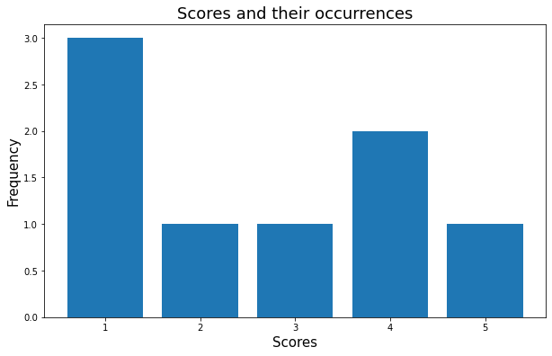

```python
references_task_18 = """
https://ipywidgets.readthedocs.io/en/latest/examples/Widget%20List.html - dropdown, button
https://ipywidgets.readthedocs.io/en/latest/examples/Widget%20Events.html - events
https://ipywidgets.readthedocs.io/en/latest/examples/Layout%20Templates.html - grid layout
https://ipywidgets.readthedocs.io/en/stable/examples/Widget%20List.html#String-widgets - html text
https://ipywidgets.readthedocs.io/en/latest/examples/Layout%20Templates.html - Grid Layout
"""


import matplotlib.pyplot as plt  # Import matplotlib library to plot a bar graph
import ipywidgets as widgets  # Import widget library for interactive jupyter notebooks
# List where each element is a dictionary with the keys product id, product name, and all scores
drop_down_list_with_scores = []
# List where each element is a string with "product id - product name" combinations
drop_down_list_no_scores = []
product_name_dict = {}  # Element of drop_down_list_with_scores
score_list = []  # List of all scores for a single product from dropdown list
# Containter to not overwrite the list and dictionaries above
container_list = []
container_dict = {}


# Loop over the list of products where each element is a dictionary
for element in products_dicts:
    container_dict["uniq_id"] = element["uniq_id"]  # Take the product id of each element of product_dicts
    container_dict["name_title"] = element["name_title"]  # Take the product name of each element of product_dicts
    uniq_id_name_str = element["uniq_id"] + " - " + element["name_title"]  # Contatenate product id and name
    drop_down_list_no_scores.append(uniq_id_name_str)  # fill the dropdown menu with the product ids and names without scores
    for key in element["Reviews"]:
        container_list.append(key["Score"])  # for each product id, retrieve the scores
    score_list = container_list.copy()
    container_dict["Score"] = score_list
    product_name_dict = container_dict.copy()
    # Fill the list where each element is a dictionary with the keys product id, product name, and a list of scores
    drop_down_list_with_scores.append(product_name_dict)
    # clear the container variables
    container_list.clear()
    container_dict.clear()


grid = widgets.GridspecLayout(3, 2,)  # Create a grid with 3 rows and 2 columns

# Create an HTML text that serves as a title
title = widgets.HTML(
    value="<h1><b>Plot Score Freuqencies</b></h1>",
    placeholder='Some HTML',
)


# Create a dropdown menu and provide the values from the list drop_down_list_no_scores
dropdown_menu = widgets.Dropdown(
    options=drop_down_list_no_scores,
    value=drop_down_list_no_scores[0],  # The first entry is the defualt value
    description='<h4>Product:</h4>',
    disabled=False,
    layout={'width': '85%'}  # Width of dropdown - Reference: https://github.com/jupyter-widgets/ipywidgets/issues/2051
)


plot_button = widgets.Button(
    description='Plot Bar Graph',
    disabled=False,
    button_style='info',  # Possible color values: success, info, warning, danger and ''
    tooltip='Plot Bar Graph',
)

def plot_score_frequencies(b):
    """
    This function displays a graph that resembles the scores for a certain product and their occurences.
    Steps:
    1. # Split the product id and product name at the charcter " - " and create a list of product id and name
    2. Retrieve the whole information about the chosen product from the dropdown menu
    3. Retrieve all scores for the chosen product
    4. Sort all the scores in ascending order
    5. Create a dataframe which contains the unique scores and their occurences as columns
    6. Check the occurences of each unique score and store them in a seperate list
    7. Create a dataframe which contains the unique scores and their occurences as columns
    8. Prepare the bar graph and display it
    """
    all_scores = []
    frequency = []
    # Split the product id and product name at the charcter " - " and create a list
    drop_down_selection = dropdown_menu.value.split(" - ")
    # Retrieve the whole information about the chosen product from the dropdown menu
    # drop_down_selection[0] has the uniq_id form the global variable products_dicts
    chosen_product = find_product(drop_down_selection[0])
    for element in drop_down_list_with_scores:
        if element["uniq_id"] == chosen_product["uniq_id"]:
            all_scores = element["Score"]  # Retrieve all scores for the chosen product and store them in a list
    all_scores.sort()  # Sort all the scores in ascending order
    set_all_scores = set(all_scores)  # remove duplicates by saving the scores in a set
    unique_scores = list(set_all_scores)  # Create a set with uniq scores by transforming the set above into a list
    # Check the occurences of each unique score and store them in a seperate list
    for element in unique_scores:
        frequency.append(all_scores.count(element))
    # Create a dataframe which contains the unique scores and their occurences as columns
    df_for_bar_graph = pandas.DataFrame({'Score': unique_scores,'frequency': frequency})
    # Prepare the bar graph
    plt.figure(figsize=(10,6))
    plt.bar('Score', 'frequency',data=df_for_bar_graph)
    plt.xlabel("Scores", size=15)
    plt.ylabel("Frequency", size=15)
    plt.title("Scores and their occurrences", size=18)
    display(plt)
    print(chosen_product)  # Reference to check if scores were counted correctly


# Embed widgets in the grid
grid[0, 0] = title
grid[1, 0] = dropdown_menu
grid[2, 0] = plot_button

plot_button.on_click(plot_score_frequencies)  # Event listener for button click: Plot a graph

display(grid)  # Display the grid
```

# Display of widgets before pressing the "Plot Bar Graph" button

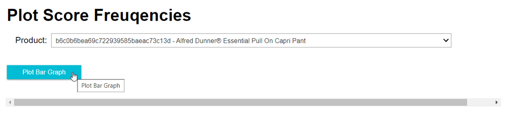

```python
widget_display = Image.open(os.path.abspath("Display of Widgets in Jupyter Notebook.png"))
display(widget_display)
```

# Choosing another product

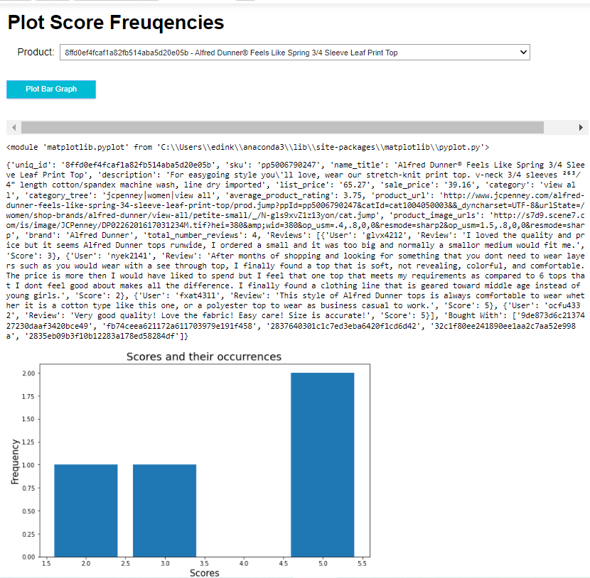

```python
alt_product_display = Image.open(os.path.abspath("Alternative_product.png"))
display(alt_product_display)
```

# Values of the dropdown menu

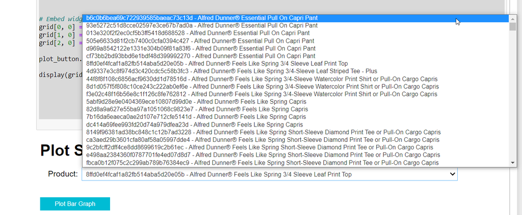

```python
# drop_down_menu_display = Image.open(f"{os.getcwd()}\Alternative_product.png")
# os.path.abspath("reviews.csv")
drop_down_menu_display = Image.open(os.path.abspath("Values of dropdown.png"))
display(drop_down_menu_display)
```

# Additional Remarks:

## The state of the widget of the could have been exported when downloading this jupyter notebook as an HTML file. When doing so, we need to embed HTML coding by clicking "Widgets" on the menu and choosing "Embed Widgets". Html coding will be displayed which can then be copied to the clipboard. Afterwards, a string (for example: html_widget) must be created where the HTML coding is stored. At the end of the jupyter notebooks file, we call HTML(html_widget). This funcionality can be executed with the help of the following statement: from IPython.core.display import HTML

## One of the reasong why I did not choose to do so and why I uploaded screenshots of the different states of my widget as an example is the slow performance. The amount of data stored in the dropdown menu would create an extremely large html string and thus decreasing the performance. One way to bypass this phenomenon is to reduce the amount of data in the dropdown menu to a few datasets. Stored as a jupyter notebook ipynb file, the widgets are still interactive

## Another thing that can be considered is to clear the data after pressing on the "Plot Bar Graph" button so that plots from previous data are not displayed anymore.